# codeschool: R basics

Sophie Paul (sophie.paul@addenbrookes.nhs.uk)

# Intro

R is a statistical programming language that is best suited for data exploration, visualisation, and modelling. In this document I will outline some basic concepts that you should be familiar with. I haven’t covered everything, but I hope this will serve as a useful starting point.

To follow this short tutorial, I recommend downloading and installing RStudio, then installing the following package by running it in the **Console**:

```r
install.packages("rmarkdown")
```

Then click the *New File* button and select R Notebook. You can enter code by creating a new cell with *CTRL+Shift+I*, and running it with *CTRL+Shift+Enter*.

Once you have your notebook ready, we can begin!

# Variables and container types

Unlike in Python, the concept of a placeholder for a single item doesn’t make much sense. R variables are typically expressed as containers of zero-to-many items (which can include a single item, if that makes sense). There are, in general, two different types of these containers:

- vectors
- lists

The main difference is that vectors are objects that can each contain only the type of data you tell them to. For example, a vector of numbers can be an `int` (integer) type, `double` (i.e. decimal place type), `complex` and so on. You can also have a `character` vector which contains string-type data.

Lists, on the other hand, are heterogenous, and can contain items of different types (the items in these cases will themselves be vectors).

# Vectors

To demonstrate, let’s take a look at this numeric vector. Have a go at typing this in yourself, and running the block either by pressing the Play button or CTRL+Shift+Enter:

(Note: if you want to run code one line at a time, you can hit just CTRL+Enter wherever your cursor is.)

```r
my_num_vector <- c(1, 2, 3, 4, 5)

my_num_vector
```

```
## [1] 1 2 3 4 5
```

This is a numeric vector with 5 integers. The `c()` function is used to create new vectors.

You can also apply functions to vectors. We can add 3 to each element:

```r
my_num_vector + 3
```

```
## [1] 4 5 6 7 8
```

…or calculate the mean:

```r
mean(my_num_vector)
```

```
## [1] 3
```

As I mentioned, there are a few different types of vector. The following is an example of a `character` vector, which contains string data:

```r
my_char_vector <- c("four", "naans", "jeremy", "that's", "insane")

my_char_vector
```

```
## [1] "four"   "naans"  "jeremy" "that's" "insane"
```

This is a character vector of length 5, each entry being a string of text.

Again, you can run functions on them (though the functions you can run on different types of vectors is different. It doesn’t make sense to take the logarithm of a bunch of text, or capitalise numbers, for example).

Here, we collapse our 5-length character vector into a 1-length character vector:

```r
paste(my_char_vector, collapse = " ")
```

```
## [1] "four naans jeremy that's insane"
```

There are also boolean vectors, which contain either TRUE or FALSE. These are mostly useful for conditional expressions, and also filtering.

```r
my_num_vector == 3
```

```
## [1] FALSE FALSE  TRUE FALSE FALSE
```

You can see that only position 3 is equal to 3 in our list of numbers (if you didn’t define your own, anyway).

Just for completeness’ sake, vectors can be multidimensional (i.e. 2D matrices, 3D arrays, etc.).

```r
matrix(c(1, 2, 3, 4, 5, 6), nrow=2)
```

```
##      [,1] [,2] [,3]
## [1,]    1    3    5
## [2,]    2    4    6
```

But this is more useful in actual maths, so I won’t cover them in detail.

## Subsetting vectors

You can also subset vectors using the `[` syntax. For example, we can get the first number out of our numeric vector:

```r
my_num_vector[1]
```

```
## [1] 1
```

…or the third element of our character vector:

```r
my_char_vector[3]
```

```
## [1] "jeremy"
```

…or, by even supplying a vector (by using `c`):

```r
my_num_vector[c(4, 5)]
```

```
## [1] 4 5
```

Boolean vectors can also be used for indexing. Here, we’ll find all of the elements with a value less than three by first creating a boolean vector:

```r
where_lt_three <- my_num_vector < 3
where_lt_three
```

```
## [1]  TRUE  TRUE FALSE FALSE FALSE
```

…then passing it to the subsetting function:

```r
my_num_vector[where_lt_three]
```

```
## [1] 1 2
```

# Functions

Before we cover lists, I want to talk about functions. R gives you access to a bunch of predefined functions (like `mean`, `t.test` and so on) that you can run on your data.

As you may have seen in the `paste` function from earlier, some functions let you set arguments that change their behaviour.

Often, you’ll want to define your own function, so units of computation can be reused many times throughout your code.

Here, we define a function that squares a number:

```r
square <- function(x){
  x**2
}
```

```r
square(my_num_vector)
```

```
## [1]  1  4  9 16 25
```

Writing good functions is an art - but, to begin with, you’ll generally want them to only do a small amount of work so they’re easy to test, and easy to put together to build more complex functions.

If you find yourself running the same block of code against data in more than two places, consider turning that block into a function, as it saves a lot of effort.

# Lists

Vectors don’t like it when different types of data are passed to it. Here, we create a vector with a numeric `1` and a character string `"two"`:

```r
wrong <- c(1, "two")
wrong
```

```
## [1] "1"   "two"
```

```r
mean(wrong)
```

```
## [1] NA
```

The vector ended up coercing all of the data to the same type (in this case, `character`). There’s an order of priority with type coercion in vectors.

On the other hand, lists can be heterogeneous:

```r
my_list <- list(1, "two", 3.5, 4, 5)

my_list
```

```
## [[1]]
## [1] 1
##
## [[2]]
## [1] "two"
##
## [[3]]
## [1] 3.5
##
## [[4]]
## [1] 4
##
## [[5]]
## [1] 5
```

This list contains many types of data, and if you subset it you’ll find the vector returned contains the data of that specific type at that position.

Additionally, not only can lists contain vectors, but they can contain lists of lists, or lists of lists of vectors, and so on. There’s no limit to the amount of nesting you can do:

```r
list(
  list(
    c(1, 2, 3)
  ),
  list(
    c("four", "five", "six")
  ),
  list(
    list(
      c(5, 6, 7)
    ),
    list(
      c(7, 8, 9)
    )
  )
)
```

```
## [[1]]
## [[1]][[1]]
## [1] 1 2 3
##
##
## [[2]]
## [[2]][[1]]
## [1] "four" "five" "six"
##
##
## [[3]]
## [[3]][[1]]
## [[3]][[1]][[1]]
## [1] 5 6 7
##
##
## [[3]][[2]]
## [[3]][[2]][[1]]
## [1] 7 8 9
```

This is a particularly important property of lists, as it allows lots of types of data structure possibilities. Many constructs in R (like data frames and `t test` objects) are actually implemented as lists, in a sense, so learning how to work with them pays off.

## Subsetting lists

Like vectors, you can subset lists:

```r
my_list[1]
```

```
## [[1]]
## [1] 1
```

```r
my_list[3]
```

```
## [[1]]
## [1] 3.5
```

However, a particularly frustrating “gotcha” with lists is that there’s more than one way to subset them, and each way has different outcomes. This means that the functions you can run on your data changes depending on the method you used.

For example, we’ll subset our list using the `[` method, which returns a list:

```r
nums <- c(my_list[1], my_list[3])
nums
```

```
## [[1]]
## [1] 1
##
## [[2]]
## [1] 3.5
```

```r
square(nums)
```

```
## Error in x^2: non-numeric argument to binary operator
```

…and we find that our `square` function failed, because `square` doesn’t work on lists.

To strip away the “list-iness”, you can use the `[[` function:

```r
my_list[[1]]
```

```
## [1] 1
```

```r
nums_v <- c(my_list[[1]], my_list[[3]])

square(nums_v)
```

```
## [1]  1.00 12.25
```

The way that helped me remember the difference is thinking of it like a box you get from Amazon, where they’ve bundled all of your impulse-purchases together in one big box, each item itself encased in bits of cardboard and plastic (which totally isn’t killing the planet).

If you want to pick up a single item from the big box and leave the packaging around it, use `[`. If you want to pick up an item and chuck away all the crap it’s encased in, use `[[`. Usually, you’ll want to do the latter.

## Named lists

You can also add names to lists (and vectors!) for additional subsetting power:

```r
names(my_list) <- c("first", "second", "third", "fourth", "fifth")

my_list["fourth"]
```

```
## $fourth
## [1] 4
```

```r
my_list[["fourth"]]
```

```
## [1] 4
```

There also exists the `$` syntax, which is just shorthand for `[[`:

```r
my_list$fourth
```

```
## [1] 4
```

## why is this important?

As I mentioned earlier, things like t tests and data frames are implemented as lists. Let’s demonstrate by running a t-test on some randomly generated normal-distributed data:

```r
group_1 <- rnorm(n = 100, mean = 6, sd = 1)
group_2 <- rnorm(n = 100, mean = 16, sd = 4)

result <- t.test(group_1, group_2)
```

Take a look at the structure of the result:

```r
str(result)
```

```
## List of 10
##  $ statistic  : Named num -25.7
##   ..- attr(*, "names")= chr "t"
##  $ parameter  : Named num 112
##   ..- attr(*, "names")= chr "df"
##  $ p.value    : num 7.26e-49
##  $ conf.int   : num [1:2] -11 -9.43
##   ..- attr(*, "conf.level")= num 0.95
##  $ estimate   : Named num [1:2] 6.05 16.27
##   ..- attr(*, "names")= chr [1:2] "mean of x" "mean of y"
##  $ null.value : Named num 0
##   ..- attr(*, "names")= chr "difference in means"
##  $ stderr     : num 0.397
##  $ alternative: chr "two.sided"
##  $ method     : chr "Welch Two Sample t-test"
##  $ data.name  : chr "group_1 and group_2"
##  - attr(*, "class")= chr "htest"
```

This means you can fetch the p value, and confidence interval for the difference in means, by subsetting-by-name:

```r
result$p.value
```

```
## [1] 7.258426e-49
```

```r
result$conf.int
```

```
## [1] -11.00499  -9.43203
## attr(,"conf.level")
## [1] 0.95
```

# Iteration

Often, you’ll want to run a function many times on a list of data. With vectors, R is written to handle this declaratively (as opposed to imperatively).

In Python, pretty much all of the programming you’ll do is imperative (i.e., say “how” you want to run things).

However, R’s functions are often *vectorised*, which means you can just run them on a vector that contains many entries, and R will handle all of the iteration behind-the-scenes.

As a reminder, here’s the result of running `square` on a vector of 5 numbers:

```r
square(my_num_vector)
```

```
## [1]  1  4  9 16 25
```

Lists are more finicky than this, as vectorised functions struggle to parse lists. The way to solve this is with looping behaviour. However, there are different ways to write loops in R.

## for-loop

Those of you familiar with languages like Python may remember the `for` loop. Here, we define a list of 5 numbers, and square them with a `for` loop, growing a vector as a result:

```r
num_list <- list(1, 2, 3, 4, 5)

for_loop_result <- numeric(0)

for (i in seq(1, length(num_list))){
  for_loop_result[i] <- square(num_list[[i]])
}

for_loop_result
```

```
## [1]  1  4  9 16 25
```

However, this is considered a suboptimal approach in R. `for` and `while` loops weren’t developed terribly well, so they’re relatively slow. Plus, it’s arguable that this leads to more code than necessary, making it harder to understand the developer’s intent.

## `apply`

R was developed with functional programming in mind, which makes use of *map*-type functions. In base R, the `apply` family of functions was written for this purpose. The idea is, you give `apply` a list, and a function, and `apply` will apply that function to each element (which IMO is more elegant than using for loops, but it’s just a style preference most of the time. Do what you think works).

There are different types of `apply` function. The most common is `lapply`, which returns a list:

```r
lapply(X = num_list, FUN = square)
```

```
## [[1]]
## [1] 1
##
## [[2]]
## [1] 4
##
## [[3]]
## [1] 9
##
## [[4]]
## [1] 16
##
## [[5]]
## [1] 25
```

There’s also `sapply`, which does the same thing but strips the list-packaging around the result, returning a vector/array/matrix etc.:

```r
sapply(X = num_list, FUN = square)
```

```
## [1]  1  4  9 16 25
```

## `purrr` syntax

Personally, I prefer the `purrr` library for this, as the syntax is easier to remember, and behaviour easier to predict. `map` returns a list, `map_dbl` returns a `double`-type vector, `map_chr` returns a character-type vector, and so on:

```r
install.packages("purrr")
```

```r
library(purrr)

map(.x = num_list, .f = square)
```

```
## [[1]]
## [1] 1
##
## [[2]]
## [1] 4
##
## [[3]]
## [1] 9
##
## [[4]]
## [1] 16
##
## [[5]]
## [1] 25
```

```r
map_dbl(.x = num_list, .f = square)
```

```
## [1]  1  4  9 16 25
```

```r
map_chr(.x = num_list, .f = paste, "MISSISSIPI")
```

```
## [1] "1 MISSISSIPI" "2 MISSISSIPI" "3 MISSISSIPI" "4 MISSISSIPI" "5 MISSISSIPI"
```

The added benefit is that this shows you how to install libraries other people have written, and import the functions from their code into your own, for your own use.

# Data Frames

Data frames are probably the data structure you’ll use the most in R. They’re implemented as lists of named vectors of the same length, as we’ll demonstrate.

We’ll make a list containing two vectors (x and y), and show you the first 5 elements:

```r
data_list <- list("x" = seq(1, 100), "y" = rnorm(100, 0, 1))

lapply(data_list, `[`, 1:5)
```

```
## $x
## [1] 1 2 3 4 5
##
## $y
## [1]  0.1847348  1.5870831 -0.4241150  1.3206699 -0.6051483
```

This can be converted straight to a data frame with the `data.frame` function:

```r
df <- data.frame(data_list)
df
```

| x | y |
| --- | --- |
| 1 | 0.184734831 |
| 2 | 1.587083095 |
| 3 | -0.424115046 |
| 4 | 1.320669881 |
| 5 | -0.605148280 |
| 6 | 0.733683319 |
| 7 | -0.114698989 |
| 8 | -0.481574101 |
| 9 | 0.745316983 |
| 10 | 0.557236750 |

[output cut: 90 more lines]

Data frames are lists of vectors, but they also have a number of special properties and methods to work with.

## Subsetting data frames

Data frame columns can be fetched by name:

```r
df$x[1]
```

```
## [1] 1
```

```r
df$y[1]
```

```
## [1] 0.1847348
```

Data frames can also be subset by row and column using the `[` operator. The syntax is `df[<ROW(s)>,<COLUMN(s)>]`:

```r
# first row
df[1,]
```

|  | x | y |
| --- | --- | --- |
| 1 | 1 | 0.1847348 |

```r
# second to fifth row
df[2:5,]
```

|  | x | y |
| --- | --- | --- |
| 2 | 2 | 1.5870831 |
| 3 | 3 | -0.4241150 |
| 4 | 4 | 1.3206699 |
| 5 | 5 | -0.6051483 |

```r
# first column
df[,1]
```

```
##   [1]   1   2   3   4   5   6   7   8   9  10  11  12  13  14  15  16  17  18
##  [19]  19  20  21  22  23  24  25  26  27  28  29  30  31  32  33  34  35  36
##  [37]  37  38  39  40  41  42  43  44  45  46  47  48  49  50  51  52  53  54
##  [55]  55  56  57  58  59  60  61  62  63  64  65  66  67  68  69  70  71  72
##  [73]  73  74  75  76  77  78  79  80  81  82  83  84  85  86  87  88  89  90
##  [91]  91  92  93  94  95  96  97  98  99 100
```

```r
# tenth to fifteenth row of second column
df[10:15,2]
```

```
## [1]  0.55723675 -0.40099053 -0.11507311  0.67304898  0.42619921 -0.02922412
```

You can also use boolean filters to extract data. We can fetch all of the negative elements, for example:

```r
where_negative <- df$y < 0

df[where_negative,]
```

|  | x | y |
| --- | --- | --- |
| 3 | 3 | -0.42411505 |
| 5 | 5 | -0.60514828 |
| 7 | 7 | -0.11469899 |
| 8 | 8 | -0.48157410 |
| 11 | 11 | -0.40099053 |
| 12 | 12 | -0.11507311 |
| 15 | 15 | -0.02922412 |
| 17 | 17 | -0.49548411 |
| 20 | 20 | -0.49412854 |
| 21 | 21 | -1.08460280 |

[output cut: 36 more lines]

## Creating new columns

New columns can also be created:

```r
df$team <- rep(c("BLUE", "RED"), 50)

df
```

| x | y | team |
| --- | --- | --- |
| 1 | 0.184734831 | BLUE |
| 2 | 1.587083095 | RED |
| 3 | -0.424115046 | BLUE |
| 4 | 1.320669881 | RED |
| 5 | -0.605148280 | BLUE |
| 6 | 0.733683319 | RED |
| 7 | -0.114698989 | BLUE |
| 8 | -0.481574101 | RED |
| 9 | 0.745316983 | BLUE |
| 10 | 0.557236750 | RED |

[output cut: 90 more lines]

## Data frame methods

You can even inspect data frames in various ways. For example, you can use `head` to peek at the first few rows:

```r
head(df)
```

|  | x | y | team |
| --- | --- | --- | --- |
| 1 | 1 | 0.1847348 | BLUE |
| 2 | 2 | 1.5870831 | RED |
| 3 | 3 | -0.4241150 | BLUE |
| 4 | 4 | 1.3206699 | RED |
| 5 | 5 | -0.6051483 | BLUE |
| 6 | 6 | 0.7336833 | RED |

Or, you can summarise the whole thing and take a look at its composition:

```r
summary(df)
```

```
##        x                y                team
##  Min.   :  1.00   Min.   :-2.21526   Length:100
##  1st Qu.: 25.75   1st Qu.:-0.52279   Class :character
##  Median : 50.50   Median : 0.07770   Mode  :character
##  Mean   : 50.50   Mean   : 0.09143
##  3rd Qu.: 75.25   3rd Qu.: 0.73810
##  Max.   :100.00   Max.   : 2.48256
```

Another cool feature is that if you call `plot()` on a data frame, it’ll draw a correlation plot for you:

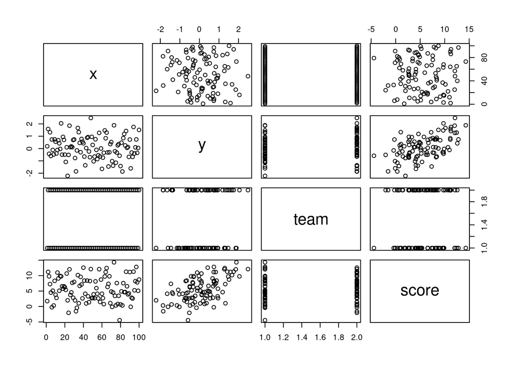

```r
df$score <- df$y * 2 + rnorm(100, mean = 5, sd = 4)
plot(df)
```

There are lots of unique methods that run on data frames, so you can take a look at these with:

```r
apropos(".data.frame$")
```

```
##  [1] "[.data.frame"             "[[.data.frame"
##  [3] "[[<-.data.frame"          "[<-.data.frame"
##  [5] "$<-.data.frame"           "aggregate.data.frame"
##  [7] "anyDuplicated.data.frame" "anyNA.data.frame"
##  [9] "as.data.frame"            "as.data.frame.data.frame"
## [11] "as.list.data.frame"       "as.matrix.data.frame"
## [13] "by.data.frame"            "cbind.data.frame"
## [15] "dim.data.frame"           "dimnames.data.frame"
## [17] "dimnames<-.data.frame"    "droplevels.data.frame"
## [19] "duplicated.data.frame"    "format.data.frame"
## [21] "is.data.frame"            "is.na.data.frame"
## [23] "Math.data.frame"          "merge.data.frame"
## [25] "Ops.data.frame"           "print.data.frame"
## [27] "rbind.data.frame"         "row.names.data.frame"
## [29] "row.names<-.data.frame"   "rowsum.data.frame"
## [31] "split.data.frame"         "split<-.data.frame"
## [33] "subset.data.frame"        "summary.data.frame"
## [35] "Summary.data.frame"       "t.data.frame"
## [37] "transform.data.frame"     "unique.data.frame"
## [39] "within.data.frame"        "xpdrows.data.frame"
## [41] "xtfrm.data.frame"
```

Take a look at the appendix for more info about how R handles class-specific function calling, but it’s not mandatory.

## About `tidyverse`

Base R data-frame operations are a little wordy, and can be a little confusing at times. This is why you’ll find a lot of data analyses are written using the [tidyverse](https://www.tidyverse.org/) ecosystem, which works like a different dialect of R. This will be covered in the codeschool session, but if you’re curious check out [R for Data Science](https://r4ds.had.co.nz/).

# Appendix

## A quick word about how class-specific “methods” work in R

You can call any of the methods you saw in `apropos(".data.frame$")` on `data.frame`-type objects just by calling the first bit of the function name. For example, instead of calling `unique.data.frame(df)`, you call `unique(df)`; instead of `summary.data.frame(df)`, you call `summary(df)`.

In other words, when you call `unique(df)`, what R does in the background is read the type of object you’re calling, and then translate this to `unique.data.frame(df)`.

If you take a look at all of the types of objects `unique()` functions have been defined for, you’ll see what I mean:

```r
apropos("^unique.")
```

```
## [1] "unique.array"           "unique.data.frame"      "unique.default"
## [4] "unique.matrix"          "unique.numeric_version" "unique.POSIXlt"
## [7] "unique.warnings"
```

In short:

- If you called `unique()` on a matrix, R would call `unique.matrix()`.
- On an array, `unique()` would be translated to `unique.array()`.
- If you called `unique()` on a character vector, R would instead translate this to `unique.default()`, because no `unique` function has been defined officially for character vectors.

This approach is called generic function programming. The R object/class system is called S3, which handles which methods to call for which types of object. You can define your own S3 classes too, so you can read up on that if you’re curious.